# 210B Lab Report 3

Anagha Uppal

3/6/2018

### PART 1:

#### Background

[output not shown]

#### Model Overview

Although we were directed to use a k-nearest neighbors method to create polygons, it resulted in a few errors in the construction of the correlogram and warninigs in the separated LM lag/error models. Therefore, we will use queen contiguity to create neighbors because there isn’t a sizable difference between the two.

```r
## Setting up and choosing libraries and importing data
setwd("~/Desktop/Anagha/UCSB/Classes/GEOG 210B/hw3")
library(spdep)
```

```r
library(maptools)
library(leaflet)
library(RColorBrewer)
library(stargazer)
## Importing data
CA.poly <- readShapePoly('LPA_Pop_Char_bg.shp')
class(CA.poly)
```

```
## [1] "SpatialPolygonsDataFrame"
## attr(,"package")
## [1] "sp"
```

```r
CA.poly@data$center = CA.poly@data$LPAgrp == 4
CA.poly@data$suburb = CA.poly@data$LPAgrp == 3
CA.poly@data$exurb = CA.poly@data$LPAgrp == 2
CA.poly@data$rural = CA.poly@data$LPAgrp == 1
CA.poly@data$none = CA.poly@data$LPAgrp == 0

YCOUNTY <- CA.poly[CA.poly@data$countyname== c("Riverside"), ]
```

```r
YCOUNTY@data$drvalpr =YCOUNTY@data$drvalM/YCOUNTY@data$n_pr #creating dependent variable
YCOUNTY@data$drvalpr[is.na(YCOUNTY@data$drvalpr)] <-0 #replace resulting NAs with 0s
```

```r
drvalOLS<-lm(drvalpr~suburb+exurb+rural+HHSIZE1+HHSIZE2+HHSIZE3+HHSIZE4+HHSIZE5+HHSIZE6+HHSIZE7, data=YCOUNTY@data) #creating linear model
summary(drvalOLS)
```

```
##
## Call:
## lm(formula = drvalpr ~ suburb + exurb + rural + HHSIZE1 + HHSIZE2 +
##     HHSIZE3 + HHSIZE4 + HHSIZE5 + HHSIZE6 + HHSIZE7, data = YCOUNTY@data)
##
## Residuals:
##      Min       1Q   Median       3Q      Max
## -11.6033  -1.0276  -0.0417   0.8840  28.4470
##
## Coefficients:
##               Estimate Std. Error t value Pr(>|t|)
## (Intercept)  7.0123260  0.2300990  30.475  < 2e-16 ***
## suburbTRUE   2.8500293  0.2144600  13.289  < 2e-16 ***
## exurbTRUE    3.9074190  0.2459570  15.887  < 2e-16 ***
## ruralTRUE    4.5910153  0.3763267  12.200  < 2e-16 ***
## HHSIZE1     -0.0042525  0.0009577  -4.440 9.96e-06 ***
## HHSIZE2      0.0049761  0.0008389   5.932 4.11e-09 ***
## HHSIZE3      0.0004611  0.0029430   0.157 0.875533
## HHSIZE4      0.0113165  0.0033147   3.414 0.000665 ***
## HHSIZE5     -0.0061340  0.0053692  -1.142 0.253540
## HHSIZE6     -0.0187561  0.0081190  -2.310 0.021079 *
## HHSIZE7     -0.0278942  0.0048917  -5.702 1.55e-08 ***
## ---
## Signif. codes:  0 '***' 0.001 '**' 0.01 '*' 0.05 '.' 0.1 ' ' 1
##
## Residual standard error: 1.959 on 1019 degrees of freedom
## Multiple R-squared:  0.448,  Adjusted R-squared:  0.4426
## F-statistic: 82.69 on 10 and 1019 DF,  p-value: < 2.2e-16
```

This non-spatial OLS regression model is statistically significant according to the F-test, with a strong R squared value of 44% (multiple and adjusted are approximately equal). Most of the chosen variables are individually significant in explaining the dependent variable.

```r
library(lmtest)
library(sandwich)
bptest(drvalOLS, studentize=TRUE)
```

```
##
##  studentized Breusch-Pagan test
##
## data:  drvalOLS
## BP = 20.063, df = 10, p-value = 0.02866
```

The BP test value is greater than the critical value of the chi-squared test; therefore, the model is heteroskedastic.

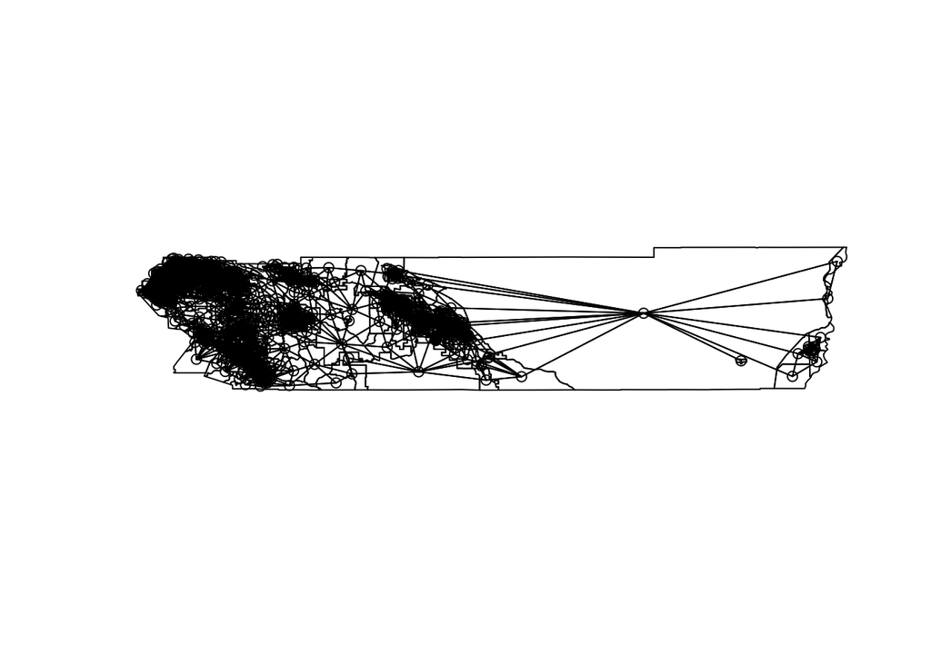

```r
#Creating the neighbors using queen contiguity
IDs<-row.names(as(YCOUNTY, "data.frame"))
coordsY<-coordinates(YCOUNTY)
plot(YCOUNTY)
list.queenY<-poly2nb(YCOUNTY, queen=T)
plot(list.queenY, coordsY, add=T)
```

```r
summary (list.queenY)
```

```
## Neighbour list object:
## Number of regions: 1030
## Number of nonzero links: 6508
## Percentage nonzero weights: 0.6134414
## Average number of links: 6.318447
## Link number distribution:
##
##   1   2   3   4   5   6   7   8   9  10  11  12  13  14  15  16  22
##   1  12  56 102 215 217 186 113  62  28  16   9   3   3   3   2   2
## 1 least connected region:
## 9993 with 1 link
## 2 most connected regions:
## 20444 20592 with 22 links
```

Found an average of 6.3 links per observation

```r
queen_w <-nb2listw(list.queenY, style="W")
summary(queen_w)
```

```
## Characteristics of weights list object:
## Neighbour list object:
## Number of regions: 1030
## Number of nonzero links: 6508
## Percentage nonzero weights: 0.6134414
## Average number of links: 6.318447
## Link number distribution:
##
##   1   2   3   4   5   6   7   8   9  10  11  12  13  14  15  16  22
##   1  12  56 102 215 217 186 113  62  28  16   9   3   3   3   2   2
## 1 least connected region:
## 9993 with 1 link
## 2 most connected regions:
## 20444 20592 with 22 links
##
## Weights style: W
## Weights constants summary:
##      n      nn   S0       S1     S2
## W 1030 1060900 1030 345.3927 4291.3
```

```r
structure(queen_w)
```

```
## Characteristics of weights list object:
## Neighbour list object:
## Number of regions: 1030
## Number of nonzero links: 6508
## Percentage nonzero weights: 0.6134414
## Average number of links: 6.318447
##
## Weights style: W
## Weights constants summary:
##      n      nn   S0       S1     S2
## W 1030 1060900 1030 345.3927 4291.3
```

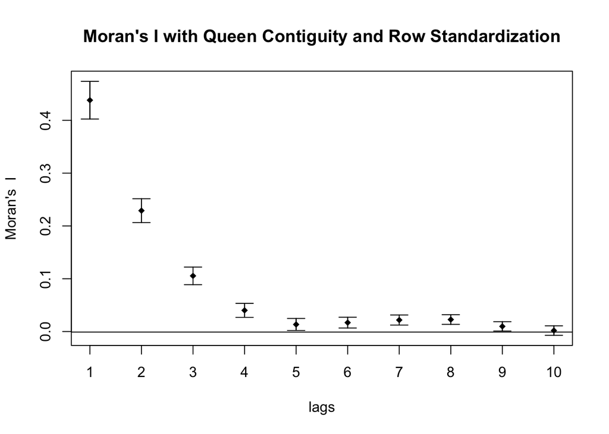

```r
mor10k <-sp.correlogram(list.queenY, var=YCOUNTY@data$drvalpr, order=10, method="I")
plot(mor10k, main ="Moran's I with Queen Contiguity and Row Standardization")
```

The first lag is by far the highest. There is definitely some spatial autocorrelation.

```r
LM<-lm.LMtests(drvalOLS, queen_w, test="all")
print(LM)
```

```
##
##  Lagrange multiplier diagnostics for spatial dependence
##
## data:
## model: lm(formula = drvalpr ~ suburb + exurb + rural + HHSIZE1 +
## HHSIZE2 + HHSIZE3 + HHSIZE4 + HHSIZE5 + HHSIZE6 + HHSIZE7, data =
## YCOUNTY@data)
## weights: queen_w
##
## LMerr = 78.348, df = 1, p-value < 2.2e-16
##
##
##  Lagrange multiplier diagnostics for spatial dependence
##
## data:
## model: lm(formula = drvalpr ~ suburb + exurb + rural + HHSIZE1 +
## HHSIZE2 + HHSIZE3 + HHSIZE4 + HHSIZE5 + HHSIZE6 + HHSIZE7, data =
## YCOUNTY@data)
## weights: queen_w
##
## LMlag = 112.56, df = 1, p-value < 2.2e-16
##
##
##  Lagrange multiplier diagnostics for spatial dependence
##
## data:
## model: lm(formula = drvalpr ~ suburb + exurb + rural + HHSIZE1 +
## HHSIZE2 + HHSIZE3 + HHSIZE4 + HHSIZE5 + HHSIZE6 + HHSIZE7, data =
## YCOUNTY@data)
## weights: queen_w
##
## RLMerr = 0.076669, df = 1, p-value = 0.7819
##
##
##  Lagrange multiplier diagnostics for spatial dependence
##
## data:
## model: lm(formula = drvalpr ~ suburb + exurb + rural + HHSIZE1 +
## HHSIZE2 + HHSIZE3 + HHSIZE4 + HHSIZE5 + HHSIZE6 + HHSIZE7, data =
## YCOUNTY@data)
## weights: queen_w
##
## RLMlag = 34.293, df = 1, p-value = 4.741e-09
##
##
##  Lagrange multiplier diagnostics for spatial dependence
##
## data:
## model: lm(formula = drvalpr ~ suburb + exurb + rural + HHSIZE1 +
## HHSIZE2 + HHSIZE3 + HHSIZE4 + HHSIZE5 + HHSIZE6 + HHSIZE7, data =
## YCOUNTY@data)
## weights: queen_w
##
## SARMA = 112.64, df = 2, p-value < 2.2e-16
```

Here, LMerr points to possible spatial error correlation, LMlag also does the same. When we move to the robust linear error model, we see that RLMerr identifies the earlier results as spurious, but RLMlag points to spatial correlation SARMA points to possible spatial lag (Y depends on neighbors) and possible spatial error correlation (u depends on neighbors). Next we will create the individual spatial dependency models. If we were to use Anselin’s flowchart, after looking at the results of the diagnostic LM test, we should focus on the spatial lag model, but for this report, we will examine all the models.

```r
SpaLag <- lagsarlm(drvalpr~suburb+exurb+rural+HHSIZE1+HHSIZE2+HHSIZE3+HHSIZE4+HHSIZE5+HHSIZE6+HHSIZE7, data=YCOUNTY, queen_w)
SpaErr<-errorsarlm(drvalpr~suburb+exurb+rural+HHSIZE1+HHSIZE2+HHSIZE3+HHSIZE4+HHSIZE5+HHSIZE6+HHSIZE7, data=YCOUNTY, queen_w)

SpaLagMix <-lagsarlm(drvalpr~suburb+exurb+rural+HHSIZE1+HHSIZE2+HHSIZE3+HHSIZE4+HHSIZE5+HHSIZE6+HHSIZE7, data=YCOUNTY, queen_w, type="mixed")

SARAR<-sacsarlm(drvalpr~suburb+exurb+rural+HHSIZE1+HHSIZE2+HHSIZE3+HHSIZE4+HHSIZE5+HHSIZE6+HHSIZE7, data=YCOUNTY, queen_w)
SARARMix<-sacsarlm(drvalpr~suburb+exurb+rural+HHSIZE1+HHSIZE2+HHSIZE3+HHSIZE4+HHSIZE5+HHSIZE6+HHSIZE7, data=YCOUNTY, queen_w, type="sacmixed")
impacts(SpaLag,listw=queen_w)
```

```
## Impact measures (lag, exact):
##                  Direct     Indirect        Total
## suburbTRUE  2.208912455  1.321812303  3.530724758
## exurbTRUE   3.039519706  1.818847340  4.858367047
## ruralTRUE   3.503679508  2.096600374  5.600279883
## HHSIZE1    -0.003977708 -0.002380259 -0.006357967
## HHSIZE2     0.004043270  0.002419491  0.006462761
## HHSIZE3     0.001672733  0.001000963  0.002673695
## HHSIZE4     0.007554449  0.004520579  0.012075029
## HHSIZE5    -0.005869457 -0.003512281 -0.009381737
## HHSIZE6    -0.015402354 -0.009216762 -0.024619116
## HHSIZE7    -0.018090570 -0.010825390 -0.028915960
```